# Linear Regression Model (Base Model)

To better understand escooter usage in Chicago over the program period a linear regression base model will be established to compare the performance of alternate machine learning models.

The model will consider independent variables from alternate data sources including weather data, taxi trip data, traffic accident data and public transport data to predict number of escooter trips. The justification for the inclusion of these data sources was the availability of the data and the logical impact that these variables may have on the number of escooter trips taken.

The regression model should provide insight into what factors contribute to the number of escooter trips (the dependent variable).

## Import Data

The following data sources were imported and merged to create the data set:

- The [E-Scooter*Trips*-_2020](https://data.cityofchicago.org/Transportation/E-Scooter-Trips-2020/3rse-fbp6) data set that contains trip data collected during the trial.
- The [Taxi*Trips*-_2020.csv](https://data.cityofchicago.org/Transportation/Taxi-Trips/wrvz-psew) data set that contains taxi trip data for Chicago
- The [CTA_-*Ridership*-_Daily_Boarding_Totals](https://data.cityofchicago.org/Transportation/CTA-Ridership-Daily-Boarding-Totals/6iiy-9s97) dataset shows boardings for both bus and rail service in Chicago
- The [Traffic Crashes - Vehicles](https://data.cityofchicago.org/Transportation/Traffic-Crashes-Vehicles/68nd-jvt3) data set contains information about vehicles involved in a traffic crash in Chicago
- The [Chicago Weather Observations Data](https://mesonet.agron.iastate.edu/request/download.phtml?network=IL_ASOS) dataset contains observed weather conditions in Chicago during the course of the trial.

```python
import pandas as pd
import numpy as np
import seaborn as sns
import matplotlib.pyplot as plt
%matplotlib inline

from sklearn.model_selection import train_test_split
from sklearn.linear_model import LinearRegression
from sklearn.metrics import mean_squared_error, mean_absolute_error
from sklearn.metrics import r2_score

import warnings # supress warnings
warnings.filterwarnings('ignore')
```

```python
df = pd.read_csv("Data\Regression_Model_Data.csv")
df= df.drop(columns='Unnamed: 0')
df.head()
```

|  | Date | Month | Day | Time | Escooter Trip Distance Total (km) | Escooter Trip Duration Total(mins) | Escooter Total Trips | Temperature_F | Humidity% | Wind_Speed_kn | Precipitation (mm) | Total Traffic Incidents | Number of Bus Trips | Number of Rail Trips | Taxi Trip Distance (km) | Taxi Total Trips |
| --- | --- | --- | --- | --- | --- | --- | --- | --- | --- | --- | --- | --- | --- | --- | --- | --- |
| 0 | 2020-08-12 | August | Wednesday | 05:00:00 | 4.058 | 31.0500 | 4 | 71.1 | 65.58 | 0.500000 | 0.0 | 3.0 | 313739 | 146680 | 248.21 | 27 |
| 1 | 2020-08-12 | August | Wednesday | 07:00:00 | 14.762 | 71.8167 | 9 | 68.0 | 75.84 | 0.583333 | 0.0 | 9.0 | 313739 | 146680 | 597.01 | 87 |
| 2 | 2020-08-12 | August | Wednesday | 08:00:00 | 47.882 | 342.5667 | 16 | 66.9 | 78.77 | 0.000000 | 0.0 | 38.0 | 313739 | 146680 | 1342.92 | 217 |
| 3 | 2020-08-12 | August | Wednesday | 09:00:00 | 99.651 | 687.9500 | 35 | 66.9 | 78.77 | 0.000000 | 0.0 | 19.0 | 313739 | 146680 | 1009.01 | 195 |
| 4 | 2020-08-12 | August | Wednesday | 10:00:00 | 191.260 | 1079.5500 | 71 | 64.9 | 81.19 | 0.000000 | 0.0 | 31.0 | 313739 | 146680 | 4080.83 | 397 |

```python
df.shape
```

```
(2274, 16)
```

```python
#per hour descriptive statistics
round(df.describe(),2)
```

|  | Escooter Trip Distance Total (km) | Escooter Trip Duration Total(mins) | Escooter Total Trips | Temperature_F | Humidity% | Wind_Speed_kn | Precipitation (mm) | Total Traffic Incidents | Number of Bus Trips | Number of Rail Trips | Taxi Trip Distance (km) | Taxi Total Trips |
| --- | --- | --- | --- | --- | --- | --- | --- | --- | --- | --- | --- | --- |
| count | 2274.00 | 2274.00 | 2274.0 | 2274.0 | 2274.00 | 2274.00 | 2274.00 | 2274.00 | 2274.00 | 2274.00 | 2274.00 | 2274.00 |
| mean | 807.19 | 4605.04 | 277.4 | 57.1 | 62.38 | 8.46 | 0.07 | 26.12 | 273941.52 | 142246.17 | 1871.31 | 263.43 |
| std | 922.97 | 5706.30 | 280.3 | 16.0 | 16.97 | 4.28 | 0.47 | 15.61 | 59884.47 | 29217.21 | 1067.04 | 166.37 |
| min | 0.00 | 0.50 | 1.0 | 25.0 | 15.91 | 0.00 | 0.00 | 0.00 | 119470.00 | 56839.00 | 18.22 | 5.00 |
| 25% | 146.92 | 707.74 | 70.0 | 43.0 | 49.56 | 5.25 | 0.00 | 14.00 | 229626.00 | 126890.00 | 982.72 | 117.00 |
| 50% | 422.33 | 2107.69 | 175.5 | 57.9 | 63.24 | 8.25 | 0.00 | 24.00 | 298801.00 | 151147.00 | 1832.55 | 256.50 |
| 75% | 1175.45 | 6500.45 | 409.0 | 70.0 | 75.92 | 10.92 | 0.00 | 36.00 | 318896.00 | 165838.00 | 2588.53 | 360.00 |
| max | 4705.20 | 32075.48 | 1429.0 | 95.0 | 100.00 | 28.50 | 11.70 | 108.00 | 349664.00 | 183544.00 | 5212.55 | 692.00 |

The descriptive statistics above relate to hourly counts and totals for each variable during the 123 day period of the escooter pilot program.

The average hourly distance travelled by escooter was 807.19km. The standard deviation was 922.97, which is relatively large compared to the mean suggesting a large spread. The average hourly duration of travel was 76.75 hours.

The average number of trips taken per hour was 277.4.

## Investigation of Numerical Variables

As the `Escooter Trip Distance Total (km)` and `Escooter Trip Duration Total(mins)` are not independent observations of the total number of trips, these values should be excluded from the model.

```python
df = df.drop(columns=['Escooter Trip Distance Total (km)', 'Escooter Trip Duration Total(mins)'])
df.shape
```

```
(2274, 14)
```

As the `Taxi Trip Distance (km)` and `Taxi Total Trips` are not independent of each other, the `Taxi Trip Distance (km)` should be dropped from the model.

```python
df = df.drop(columns=['Taxi Trip Distance (km)'])
df.shape
```

```
(2274, 13)
```

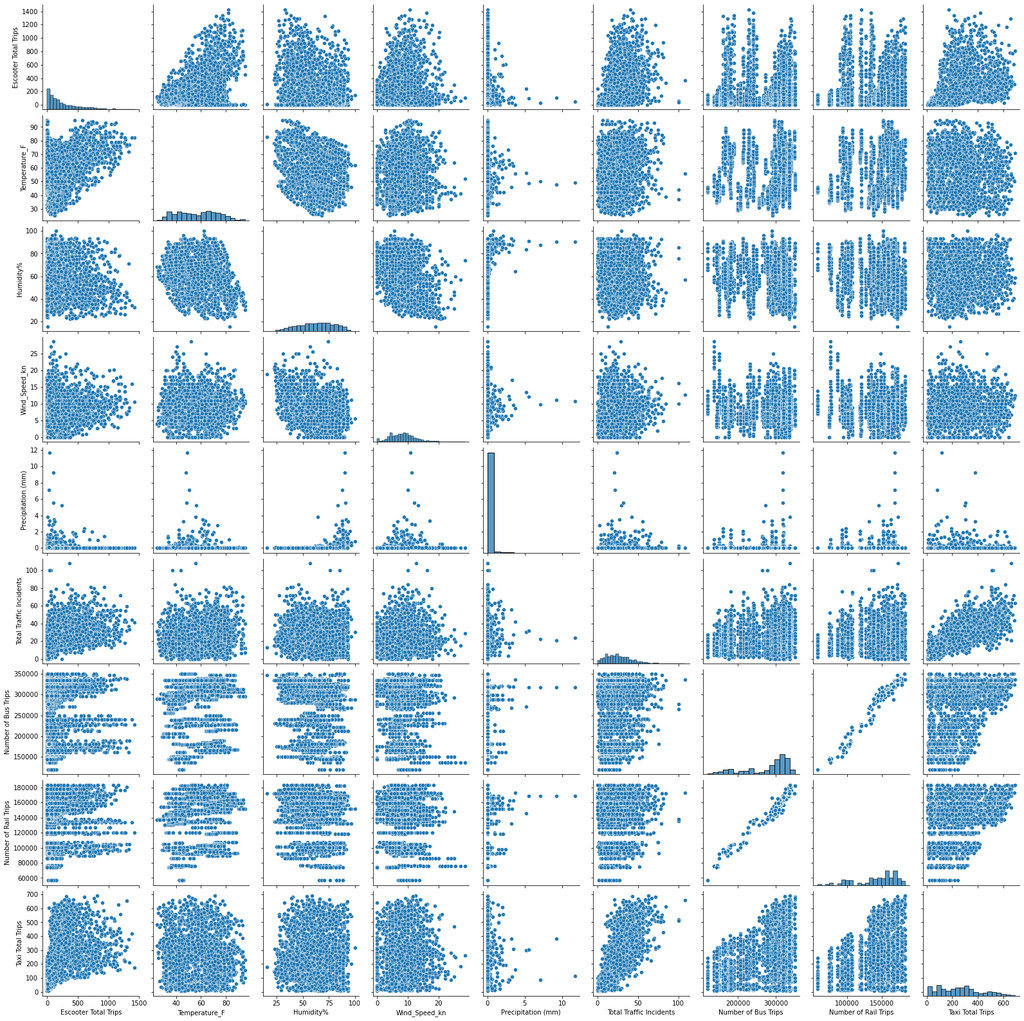

```python
sns.pairplot(data=df)
```

A weak positive linear relationship could exist between number of escooter trips taken each hour and `Temperature_F`. Also, a positive relationship may exist between number of escooter trips and `Total Traffic Inidents`. Three distinct relationships can be observed between number of escooter trips and the `public_trans` data. This may be due to differences in publis transport use during different days of the week which correlate with escooter usage. `Humidity%`, `Wind_Speed_kn` and `Taxi Total Trips` do not seem to share a linear realtionship with escooter trips.

A strong linear relationship can be observed between `Number of Bus Trips` and `Number of Rail Trips`. To prevent multicollinearity issues one of these attributes should be dropped from the model.

```python
df = df.drop(columns=['Number of Rail Trips'])
df.shape
```

```
(2274, 12)
```

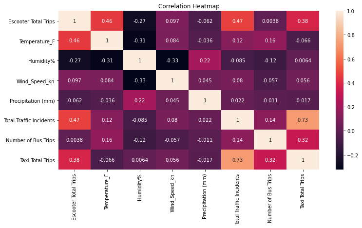

```python
plt.figure(figsize=(12,6))
sns.heatmap(df.corr(), annot = True)
plt.title('Correlation Heatmap')
plt.show()
```

A number of variables including, `Temperature_F`, `Total Traffic Incidents` and `Taxi Total Trips` show a weak positive relationship with the number of escooter trips. A weak negative relationship can be observed between `Humidity%` and number of escooter trips. Little relationship can be observed between escooter trips and `Wind_Speed_kn` and `Number of Bus Trips`.

## Regression Model (Numerical Variables Only)

Firstly a regression model fitting only the numerical variables will be fitted and performance evaluated. The data will first be split into training and testing data.

```python
df_num = df.drop(columns=['Date', 'Month', 'Day', 'Time'])
df_num.head()
```

|  | Escooter Total Trips | Temperature_F | Humidity% | Wind_Speed_kn | Precipitation (mm) | Total Traffic Incidents | Number of Bus Trips | Taxi Total Trips |
| --- | --- | --- | --- | --- | --- | --- | --- | --- |
| 0 | 4 | 71.1 | 65.58 | 0.500000 | 0.0 | 3.0 | 313739 | 27 |
| 1 | 9 | 68.0 | 75.84 | 0.583333 | 0.0 | 9.0 | 313739 | 87 |
| 2 | 16 | 66.9 | 78.77 | 0.000000 | 0.0 | 38.0 | 313739 | 217 |
| 3 | 35 | 66.9 | 78.77 | 0.000000 | 0.0 | 19.0 | 313739 | 195 |
| 4 | 71 | 64.9 | 81.19 | 0.000000 | 0.0 | 31.0 | 313739 | 397 |

```python
train, test = train_test_split(df_num, random_state=100)
print(train.shape)
print(test.shape)
```

```
(1705, 8)
(569, 8)
```

```python
feature_cols = ['Temperature_F', 'Humidity%', 'Wind_Speed_kn', 'Total Traffic Incidents', 'Number of Bus Trips', 'Taxi Total Trips']

X_train = train[feature_cols]
y_train = train['Escooter Total Trips']
X_test = test[feature_cols]
y_test = test['Escooter Total Trips']

print(f'X_train shape: {X_train.shape}')
print(f'y_train shape: {y_train.shape}')
print(f'X_test shape: {X_test.shape}')
print(f'y_test shape: {y_test.shape}')
```

```
X_train shape: (1705, 6)
y_train shape: (1705,)
X_test shape: (569, 6)
y_test shape: (569,)
```

```python
#fitting the model and predicting on test data
linreg = LinearRegression()
linreg.fit(X_train, y_train)
y_pred = linreg.predict(X_test)
print ('MAE:', mean_absolute_error(y_test, y_pred))
print ('MSE:', mean_squared_error(y_test, y_pred))
print ('RMSE:', np.sqrt(mean_squared_error(y_test, y_pred)))
print ('R2:', r2_score(y_test, y_pred))
```

```
MAE: 146.6514832912157
MSE: 38903.13853829788
RMSE: 197.23878558310452
R2: 0.4663275689251728
```

The RMSE of 197.24 is large relative to the mean which suggests that the model does not perfom well in predicting the hourly number of escooter trips.

The $R^2$ value indicates that the model explains only 46.6% of the variation in the number of escoter trips taken.

```python
# pair the feature names with the coefficients
print(list(zip(feature_cols, linreg.coef_)))
```

```
[('Temperature_F', 7.968734501688214), ('Humidity%', -2.4469230159744306), ('Wind_Speed_kn', -1.6305653406018739), ('Total Traffic Incidents', 3.201657214977603), ('Number of Bus Trips', -0.001042496745794282), ('Taxi Total Trips', 0.5995347842253538)]
```

Interpretation of the coefficients, holding all other features constant,:

- A 1 unit increase in `Temperature_F` is associated with a increase of 7.9687 escooter trips
- A 1 unit increase in `Humidity%` is associated with a decrease of 2.4469 escooter trips
- A 1 unit increase in `Wind_Speed_kn` is associated with a decrease of 1.6305 escooter trips
- A 1 unit increase in `Total Traffic Incidents` is associated with a increase of 3.2017 escooter trips
- A 1 unit increase in `Number of Bus Trips` is associated with a decrease of 0.0010 escooter trips
- A 1 unit increase in `Taxi Total Trips` is associated with a increase of 0.5995 escooter trips

```python
#fitting the model and predicting on training data
y_pred_train = linreg.predict(X_train)
print ('MAE:', mean_absolute_error(y_train, y_pred_train))
print ('MSE:', mean_squared_error(y_train, y_pred_train))
print ('RMSE:', np.sqrt(mean_squared_error(y_train, y_pred_train)))
print ('R2:', r2_score(y_train, y_pred_train))
```

```
MAE: 153.9199391531884
MSE: 43136.08877039146
RMSE: 207.69229347857726
R2: 0.4635959605498505
```

When the model was run on the training data the $R^2$ is similar to when run on the test data. This would suggest that the model is not overfitting.

Due to the poor performance of the model based on numerical variables only, the categorical variables which consider the month, time and day at which a trip was taken will be included within the model.

## Investigation of Categorical Variables

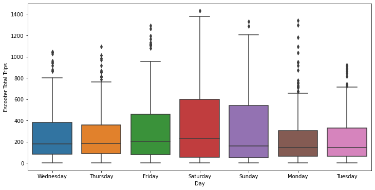

```python
plt.figure(figsize=(12,6))
sns.boxplot(x="Day", y="Escooter Total Trips", data=df)
```

A difference can be obseved between the median hourly number of escooter trips depending on the day of the week. Saturdays and Fridays seem to have larger median trips then the rest of the week. The variability on Staurdays and Sundays is much larger than the rest of the week.

The day of the week may play an important role in modeling number of escooter trips and should be included in the model.

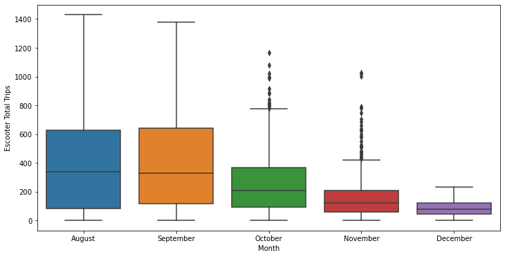

```python
plt.figure(figsize=(12,6))
sns.boxplot(x="Month", y="Escooter Total Trips", data=df)
```

August and September show the largest and similar median values. They are different from the other months and suggests that month may play an important role in predicting the number of escooter trips.

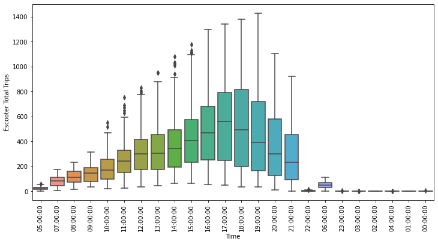

```python
plt.figure(figsize=(12,6))
sns.boxplot(x="Time", y="Escooter Total Trips", data=df)
plt.xticks(rotation=90)
plt.show()
```

The differences in the boxplots for the time of suggest that `Time` should play a significant role in modeling the number of escooter trips taken.

## Regression Model (Dummy variables included)

```python
#creating dummy variables for day category
df_dummies = pd.get_dummies(df['Month'])
df=pd.concat([df,df_dummies], axis =1)
df=df.drop(columns='August')
df_dummies = pd.get_dummies(df['Day'])
df=pd.concat([df,df_dummies], axis =1)
df=df.drop(columns='Monday')
df_dummies = pd.get_dummies(df['Time'])
df=pd.concat([df,df_dummies], axis =1)
df=df.drop(columns='00:00:00')
df.head()
```

|  | Date | Month | Day | Time | Escooter Total Trips | Temperature_F | Humidity% | Wind_Speed_kn | Precipitation (mm) | Total Traffic Incidents | ... | 14:00:00 | 15:00:00 | 16:00:00 | 17:00:00 | 18:00:00 | 19:00:00 | 20:00:00 | 21:00:00 | 22:00:00 | 23:00:00 |
| --- | --- | --- | --- | --- | --- | --- | --- | --- | --- | --- | --- | --- | --- | --- | --- | --- | --- | --- | --- | --- | --- |
| 0 | 2020-08-12 | August | Wednesday | 05:00:00 | 4 | 71.1 | 65.58 | 0.500000 | 0.0 | 3.0 | ... | 0 | 0 | 0 | 0 | 0 | 0 | 0 | 0 | 0 | 0 |
| 1 | 2020-08-12 | August | Wednesday | 07:00:00 | 9 | 68.0 | 75.84 | 0.583333 | 0.0 | 9.0 | ... | 0 | 0 | 0 | 0 | 0 | 0 | 0 | 0 | 0 | 0 |
| 2 | 2020-08-12 | August | Wednesday | 08:00:00 | 16 | 66.9 | 78.77 | 0.000000 | 0.0 | 38.0 | ... | 0 | 0 | 0 | 0 | 0 | 0 | 0 | 0 | 0 | 0 |
| 3 | 2020-08-12 | August | Wednesday | 09:00:00 | 35 | 66.9 | 78.77 | 0.000000 | 0.0 | 19.0 | ... | 0 | 0 | 0 | 0 | 0 | 0 | 0 | 0 | 0 | 0 |
| 4 | 2020-08-12 | August | Wednesday | 10:00:00 | 71 | 64.9 | 81.19 | 0.000000 | 0.0 | 31.0 | ... | 0 | 0 | 0 | 0 | 0 | 0 | 0 | 0 | 0 | 0 |

5 rows × 45 columns

```python
df.shape
```

```
(2274, 45)
```

Dummy variables were included within the dataframe so that categorical variables could be factored into the model. The month of August, day of Monday, and time of `00:00:00` (12 midnight) were selected as the baseline levels for the included categories. As such, these columns were removed from the dataframe.

```python
train, test = train_test_split(df, random_state=45)
print(train.shape)
print(test.shape)
```

```
(1705, 45)
(569, 45)
```

```python
X_train = train.drop(columns=['Date', 'Month', 'Day','Time', 'Escooter Total Trips'])
y_train = train['Escooter Total Trips']
X_test = test.drop(columns=['Date', 'Month', 'Day','Time', 'Escooter Total Trips'])
y_test = test['Escooter Total Trips']

print(f'X_train shape: {X_train.shape}')
print(f'y_train shape: {y_train.shape}')
print(f'X_test shape: {X_test.shape}')
print(f'y_test shape: {y_test.shape}')
```

```
X_train shape: (1705, 40)
y_train shape: (1705,)
X_test shape: (569, 40)
y_test shape: (569,)
```

```python
#fitting the model and predicting on test data
linreg = LinearRegression()
linreg.fit(X_train, y_train)
y_pred = linreg.predict(X_test)
print ('MAE:', mean_absolute_error(y_test, y_pred))
print ('MSE:', mean_squared_error(y_test, y_pred))
print ('RMSE:', np.sqrt(mean_squared_error(y_test, y_pred)))
print ('R2:', r2_score(y_test, y_pred))
```

```
MAE: 117.26800325890385
MSE: 23681.24191751548
RMSE: 153.8871077040422
R2: 0.6995518178481801
```

A significant improvement can be observed between the linear regression model which uses only numerical variables and the linear regression model that uses both numerical and categorical variables.

The $R^2$ indicates that the model explains 69.95% of the variation in the dependent variable.

```python
# pair the feature names with the coefficients

print(list(zip(X_train.columns.values.tolist(), linreg.coef_)))
```

[output not shown]

Interpretation of the coefficients for the month variables, holding all other features constant:

- `December` is associated with a escooter trip decrease of 69.6845 compared to `August`
- `November` is associated with a escooter trip decrease of 47.1385 compared to `August`
- `October` is associated with a escooter trip increase of 28.3420 compared to `August`
- `September` is associated with a escooter trip increase of 119.7833 compared to `August`

Interpretation of the coefficients for the weekday variables, holding all other features constant:

- `Tuesday` is associated with a escooter trip decrease of 19.2352 compared to `Monday`
- `Wednesday` is associated with a escooter trip decrease of 0.3804 compared to `Monday`
- `Thursday` is associated with a escooter trip decrease of 9.4590 compared to `Monday`
- `Friday` is associated with a escooter trip increase of 60.6960 compared to `Monday`
- `Saturday` is associated with a escooter trip increase of 154.8083 compared to `Monday`
- `Sunday` is associated with a escooter trip increase of 125.5704 compared to `Monday`

Interpretation of the coefficients for the Time variables, holding all other features constant:

```python
#fitting the model and predicting on training data
y_pred_train = linreg.predict(X_train)
print ('MAE:', mean_absolute_error(y_train, y_pred_train))
print ('MSE:', mean_squared_error(y_train, y_pred_train))
print ('RMSE:', np.sqrt(mean_squared_error(y_train, y_pred_train)))
print ('R2:', r2_score(y_train, y_pred_train))
```

```
MAE: 112.9682558730213
MSE: 22559.631595752064
RMSE: 150.19864045906695
R2: 0.7122520676146524
```

When the model was run on the training data the $R^2$ is similar to when run on the test data. This would suggest that the model is not overfitting.

## Summary

Originally 14 variables were assessed for suitability to be included within the model.

A number of variables were dropped from the model as they were considered to be not independent observations, a base assumption of a linear regression model.

From the pair plot no strong linear relationships were evident between the dependent and independent variables. A weak positive linear relationship was observed between escooter trips and temperature and possibly between escooter trips and traffic incidents. A strong positive relationship was observed between bus trips and rail trips. To prevent multicollinearity issues with the model, the number of rail trips variable was removed.

A correlation heatmap reinforced the existence of a weak positive relationship between escooter trips and temperature, and escooter trips and total traffic incidents. The positive relationship with escooter and temperature makes sense as traveling by escooter is an outdoor activity, logically the weather would make an impact on a users decision to travel by escooter. Interestingly there was no correlation observed between precipitation and escooter trips. The correlation between escooter trips and traffic incidents may be due to a confounding variable such as more people traveling.

The categorical variables, month, day and time were analysed and it was observed that these categorical variables could have a significant effect on the prediction of escooter trips. This was reinforced by the improved performance of the model with both numerical and categorical variables compared to the model with only numerical variables.

The first model run included only the numerical variables. The RMSE of the model was 197.24 which is relatively large in comparison to the mean. 46.6% of the variation in escooter trips is explained by the model. This model performs poorly in predicting the hourly number of escooter trips.